# MovieLens Project Solution Submission

### `Project - MovieLens Data Analysis`

The GroupLens Research Project is a research group in the Department of Computer Science and Engineering at the University of Minnesota. The data is widely used for collaborative filtering and other filtering solutions. However, we will be using this data to act as a means to demonstrate our skill in using Python to “play” with data.

### `Objective:`

- To implement the techniques learnt as a part of the course.

### `Learning Outcomes:`

- Exploratory Data Analysis
- Visualization using Python
- Pandas – groupby, merging

### `Domain`

- Internet and Entertainment

**Note that the project will need you to apply the concepts of groupby and merging extensively.**

### `Datasets Information:`

*rating.csv:* It contains information on ratings given by the users to a particular movie.

- user id: id assigned to every user
- movie id: id assigned to every movie
- rating: rating given by the user
- timestamp: Time recorded when the user gave a rating

*movie.csv:* File contains information related to the movies and their genre.

- movie id: id assigned to every movie
- movie title: Title of the movie
- release date: Date of release of the movie
- Action: Genre containing binary values (1 - for action 0 - not action)
- Adventure: Genre containing binary values (1 - for adventure 0 - not adventure)
- Animation: Genre containing binary values (1 - for animation 0 - not animation)
- Children’s: Genre containing binary values (1 - for children's 0 - not children's)
- Comedy: Genre containing binary values (1 - for comedy 0 - not comedy)
- Crime: Genre containing binary values (1 - for crime 0 - not crime)
- Documentary: Genre containing binary values (1 - for documentary 0 - not documentary)
- Drama: Genre containing binary values (1 - for drama 0 - not drama)
- Fantasy: Genre containing binary values (1 - for fantasy 0 - not fantasy)
- Film-Noir: Genre containing binary values (1 - for film-noir 0 - not film-noir)
- Horror: Genre containing binary values (1 - for horror 0 - not horror)
- Musical: Genre containing binary values (1 - for musical 0 - not musical)
- Mystery: Genre containing binary values (1 - for mystery 0 - not mystery)
- Romance: Genre containing binary values (1 - for romance 0 - not romance)
- Sci-Fi: Genre containing binary values (1 - for sci-fi 0 - not sci-fi)
- Thriller: Genre containing binary values (1 - for thriller 0 - not thriller)
- War: Genre containing binary values (1 - for war 0 - not war)
- Western: Genre containing binary values (1 - for western - not western)

*user.csv:* It contains information of the users who have rated the movies.

- user id: id assigned to every user
- age: Age of the user
- gender: Gender of the user
- occupation: Occupation of the user
- zip code: Zip code of the use

**`Please provide you insights wherever necessary.`**

### 1. Import the necessary packages - 2.5 marks

```python
# imoprt all the necessary libraries
import numpy as np
import pandas as pd
import matplotlib.pyplot as plt
import seaborn as sns
sns.set(color_codes=True)
%matplotlib inline
import warnings
warnings.filterwarnings('ignore')
```

### 2. Read the 3 datasets into dataframes - 2.5 marks

```python
# Read the three datasets into different dataframes
rating=pd.read_csv('data.csv')
movies=pd.read_csv('item.csv')
user=pd.read_csv('user.csv')
```

### 3. Apply info, shape, describe, and find the number of missing values in the data - 5 marks

- Note that you will need to do it for all the three datasets seperately

```python
rating.info()
```

```
<class 'pandas.core.frame.DataFrame'>
RangeIndex: 100000 entries, 0 to 99999
Data columns (total 4 columns):
 #   Column     Non-Null Count   Dtype
---  ------     --------------   -----
 0   user id    100000 non-null  int64
 1   movie id   100000 non-null  int64
 2   rating     100000 non-null  int64
 3   timestamp  100000 non-null  int64
dtypes: int64(4)
memory usage: 3.1 MB
```

```python
movies.info()
```

```
<class 'pandas.core.frame.DataFrame'>
RangeIndex: 1681 entries, 0 to 1680
Data columns (total 22 columns):
 #   Column        Non-Null Count  Dtype
---  ------        --------------  -----
 0   movie id      1681 non-null   int64
 1   movie title   1681 non-null   object
 2   release date  1681 non-null   object
 3   unknown       1681 non-null   int64
 4   Action        1681 non-null   int64
 5   Adventure     1681 non-null   int64
 6   Animation     1681 non-null   int64
 7   Childrens     1681 non-null   int64
 8   Comedy        1681 non-null   int64
 9   Crime         1681 non-null   int64
 10  Documentary   1681 non-null   int64
 11  Drama         1681 non-null   int64
 12  Fantasy       1681 non-null   int64
 13  Film-Noir     1681 non-null   int64
 14  Horror        1681 non-null   int64
 15  Musical       1681 non-null   int64
 16  Mystery       1681 non-null   int64
 17  Romance       1681 non-null   int64
 18  Sci-Fi        1681 non-null   int64
 19  Thriller      1681 non-null   int64
 20  War           1681 non-null   int64
 21  Western       1681 non-null   int64
dtypes: int64(20), object(2)
memory usage: 289.0+ KB
```

```python
user.info()
```

```
<class 'pandas.core.frame.DataFrame'>
RangeIndex: 943 entries, 0 to 942
Data columns (total 5 columns):
 #   Column      Non-Null Count  Dtype
---  ------      --------------  -----
 0   user id     943 non-null    int64
 1   age         943 non-null    int64
 2   gender      943 non-null    object
 3   occupation  943 non-null    object
 4   zip code    943 non-null    object
dtypes: int64(2), object(3)
memory usage: 37.0+ KB
```

```python
rating.shape
```

```
(100000, 4)
```

```python
movies.shape
```

```
(1681, 22)
```

```python
user.shape
```

```
(943, 5)
```

```python
rating.describe
```

```
<bound method NDFrame.describe of        user id  movie id  rating  timestamp
0          196       242       3  881250949
1          186       302       3  891717742
2           22       377       1  878887116
3          244        51       2  880606923
4          166       346       1  886397596
...        ...       ...     ...        ...
99995      880       476       3  880175444
99996      716       204       5  879795543
99997      276      1090       1  874795795
99998       13       225       2  882399156
99999       12       203       3  879959583

[100000 rows x 4 columns]>
```

```python
movies.describe
```

```
<bound method NDFrame.describe of       movie id                          movie title release date  unknown  \
0            1                           Toy Story   01-Jan-1995        0
1            2                           GoldenEye   01-Jan-1995        0
2            3                          Four Rooms   01-Jan-1995        0
3            4                          Get Shorty   01-Jan-1995        0
4            5                             Copycat   01-Jan-1995        0
...        ...                                  ...          ...      ...
1676      1678                          Mat' i syn   06-Feb-1998        0
1677      1679                           B. Monkey   06-Feb-1998        0
1678      1680                       Sliding Doors   01-Jan-1998        0
1679      1681                        You So Crazy   01-Jan-1994        0
1680      1682  Scream of Stone (Schrei aus Stein)   08-Mar-1996        0

      Action  Adventure  Animation  Childrens  Comedy  Crime  ...  Fantasy  \
0          0          0          1          1       1      0  ...        0
```

[output cut: 38 more lines]

```python
user.describe
```

```
<bound method NDFrame.describe of      user id  age gender     occupation zip code
0          1   24      M     technician    85711
1          2   53      F          other    94043
2          3   23      M         writer    32067
3          4   24      M     technician    43537
4          5   33      F          other    15213
..       ...  ...    ...            ...      ...
938      939   26      F        student    33319
939      940   32      M  administrator    02215
940      941   20      M        student    97229
941      942   48      F      librarian    78209
942      943   22      M        student    77841

[943 rows x 5 columns]>
```

```python
# find the number of missing values in the data
rating.isnull().sum()
```

```
user id      0
movie id     0
rating       0
timestamp    0
dtype: int64
```

```python
# find the number of missing values in the data
movies.isnull().sum()
```

```
movie id        0
movie title     0
release date    0
unknown         0
Action          0
Adventure       0
Animation       0
Childrens       0
Comedy          0
Crime           0
Documentary     0
Drama           0
Fantasy         0
Film-Noir       0
Horror          0
Musical         0
Mystery         0
Romance         0
Sci-Fi          0
Thriller        0
War             0
Western         0
dtype: int64
```

```python
# find the number of missing values in the data
user.isnull().sum()
```

```
user id       0
age           0
gender        0
occupation    0
zip code      0
dtype: int64
```

### 4. Find the number of movies per genre using the item data - 2.5 marks

```python
movie_genre=movies.drop(['movie id','release date','movie title'],axis=1)  #make a dataframe which has only different genre column in it
print('No. of movies per genre:')
movie_genre.sum()   #find the sum which will give number of movies per genre
```

```
No. of movies per genre:
```

```
unknown          1
Action         251
Adventure      135
Animation       42
Childrens      122
Comedy         505
Crime          109
Documentary     50
Drama          725
Fantasy         22
Film-Noir       24
Horror          92
Musical         56
Mystery         61
Romance        247
Sci-Fi         101
Thriller       251
War             71
Western         27
dtype: int64
```

### 5. Drop the movie where the genre is unknown - 2.5 marks

```python
movie_du=movies.copy() #make a copy of the dataframe
movie_d = movie_du[movie_du['unknown']!=1]#make a dataframe which has movies with all genre except 'unknown'
```

```python
movie_d[movie_du['unknown']==1] #check whether dataframe has the movie where the genre is 'unknown'
```

|  | movie id | movie title | release date | unknown | Action | Adventure | Animation | Childrens | Comedy | Crime | ... | Fantasy | Film-Noir | Horror | Musical | Mystery | Romance | Sci-Fi | Thriller | War | Western |
| --- | --- | --- | --- | --- | --- | --- | --- | --- | --- | --- | --- | --- | --- | --- | --- | --- | --- | --- | --- | --- | --- |

0 rows × 22 columns

### 6. Find the movies that have more than one genre - 5 marks

hint: use sum on the axis = 1

Display movie name, number of genres for the movie in dataframe

and also print(total number of movies which have more than one genres)

```python
movies_mgenre=movies.drop(['movie id','release date'],axis=1) #make a new dataframe by dropping the column which are not needed
movies_mgenre['genre_no']=movies_mgenre.sum(axis=1)  #add a new column to the dataframe by applying sum which results as number of genres for each movie in dataframe
print('Dispaying movie name and no. of genres for the movie in dataframe:')
movies_mgenre[['movie title','genre_no']]  #Displaying movie name (movie title), number of genres (genre_no) for the movie in dataframe
```

```
Dispaying movie name and no. of genres for the movie in dataframe:
```

|  | movie title | genre_no |
| --- | --- | --- |
| 0 | Toy Story | 3 |
| 1 | GoldenEye | 3 |
| 2 | Four Rooms | 1 |
| 3 | Get Shorty | 3 |
| 4 | Copycat | 3 |
| ... | ... | ... |
| 1676 | Mat' i syn | 1 |
| 1677 | B. Monkey | 2 |
| 1678 | Sliding Doors | 2 |
| 1679 | You So Crazy | 1 |
| 1680 | Scream of Stone (Schrei aus Stein) | 1 |

1681 rows × 2 columns

```python
movies_mgenre=movies_mgenre[movies_mgenre['genre_no']>1] #filter out the movies which have more than one genres
movies_mgenre[['movie title','genre_no']] #display the movies which have more than one genres
print('\ntotal no.of movies which have more than one genre:' , movies_mgenre['movie title'].count())
#find the total no.of movies which have more than one genre by using count function on 'movie title' in the dataframe as we have already filtered out the movie which have more than one genre
```

```
total no.of movies which have more than one genre: 849
```

### 7. Univariate plots of columns: 'rating', 'Age', 'release year', 'Gender' and 'Occupation' - 10 marks

*HINT: Use distplot for age. Use lineplot or countplot for release year.*

*HINT: Plot percentages in y-axis and categories in x-axis for ratings, gender and occupation*

*HINT: Please refer to the below snippet to understand how to get to release year from release date. You can use str.split() as depicted below or you could convert it to pandas datetime format and extract year (.dt.year)*

```python
a = 'My*cat*is*brown'
print(a.split('*')[3])

#similarly, the release year needs to be taken out from release date

#also you can simply slice existing string to get the desired data, if we want to take out the colour of the cat

print(a[10:])
print(a[-5:])
```

```
brown
brown
brown
```

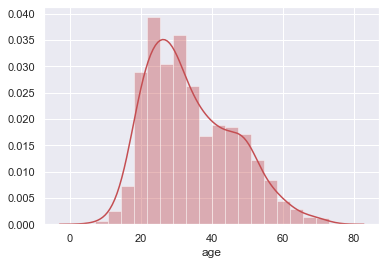

```python
sns.distplot(user['age'],color='R'); #visualising the data for 'age'
```

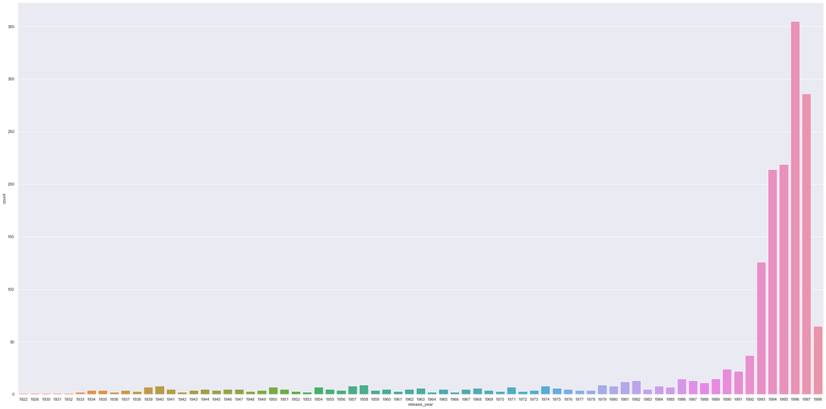

```python
movies['release_year'] = pd.DatetimeIndex(movies['release date']).year #extracting release_year from 'release_date' and adding a new column 'release_year' in the dataframe
plt.figure(figsize=(40,20)) #magnifying the plot for clear visualization or to avoid overlapping of data.
sns.countplot(movies['release_year']); #visualise the data by using countplot.
```

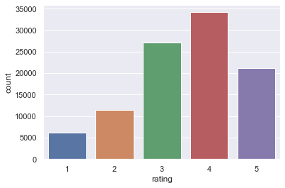

```python
sns.countplot(rating['rating']); #visualise the data by using countplot
```

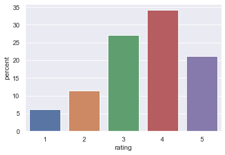

```python
# considering percentage
rating_new=rating[['user id','rating']] # make a new dataframe which has user id and rating from original dataframe
rating_new=rating_new.groupby('rating').count() # take count of user id for different ratings(this represents these many users have different rating)
rating_new['percent']=rating_new.div(rating_new['user id'].sum())*100 #find out the percent
sns.barplot(x=rating_new.index,y='percent',data=rating_new); #visualise the data in percent by using barplot
```

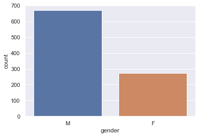

```python
  sns.countplot(user['gender']); #visualise the data by using countplot
```

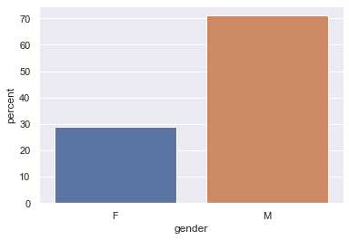

```python
# considering percentage
user_new=user[['user id','gender']] # make a new dataframe which has user id and gender from original dataframe
user_new=user_new.groupby('gender').count() # take count of user id for different gender(this represents these many users are of different gender)
user_new['percent']=user_new.div(user_new['user id'].sum())*100 #find out the percent
user_new
sns.barplot(x=user_new.index,y='percent',data=user_new); #visualise the data in percent by using barplot
```

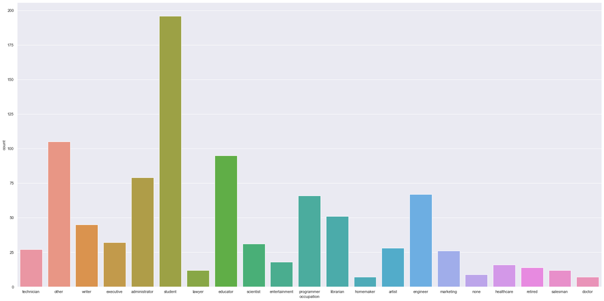

```python
plt.figure(figsize=(30,15))
sns.countplot(user['occupation']); #visualise the data by using plot
```

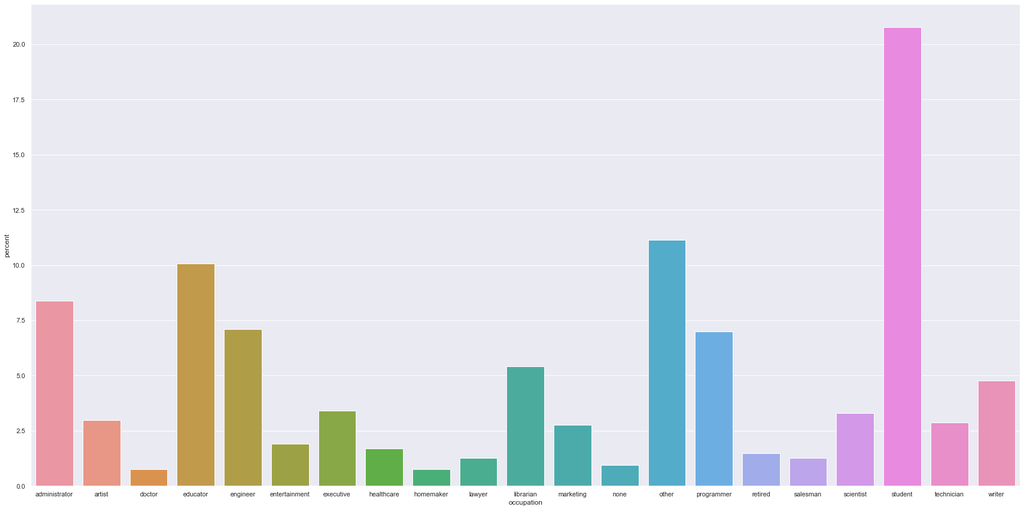

```python
# considering percentage
user_new_1=user[['user id','occupation']] # make a new dataframe which has user id and occupation from original dataframe
user_new_1=user_new_1.groupby('occupation').count() # take count of user id for different occupation(this represents these many users are of different occupation)
user_new_1['percent']=user_new_1.div(user_new_1['user id'].sum())*100 #find out the percent
plt.figure(figsize=(30,15)) # for closer look
sns.barplot(x=user_new_1.index,y='percent',data=user_new_1); #visualise the data in percent by using barplot
```

1. Visualize how popularity of genres has changed over the years - 10 marks

Note that you need to use the **percent of number of releases in a year** as a parameter of popularity of a genre

Hint 1: You need to reach to a data frame where the release year is the index and the genre is the column names (one cell shows the number of release in a year in one genre) or vice versa. (Drop unnecessary column if there are any)

Hint 2: Find the total number of movies release in a year(use `sum(axis=1)` store that value in a new column as 'total'). Now divide the value of each genre in that year by total to get percentage number of release in a particular year. `(df.div(df['total'], axis= 0) * 100)`

Once that is achieved, you can either use univariate plots or can use the heatmap to visualise all the changes over the years in one go.

Hint 3: Use groupby on the relevant column and use sum() on the same to find out the number of releases in a year/genre.

```python
movies_popgen=movies.drop(['movie id','movie title','release date'],axis=1)#create a new dataframe by dropping column which is not necessary
movies_popgen.set_index('release_year', inplace=True) # set the release_year as the index.
movies_popgen['total']= movies_popgen.sum(axis=1) # find the sum along the row and save it in a new column 'total'.
grouped_year=movies_popgen.groupby('release_year').sum() #groupby on 'release_year' in order to find out the number of releases in a year
print('\nTotal number of release in different year of differnt genre:',grouped_year['total'].sum())
grouped_year=(grouped_year.div(grouped_year['total'],axis=0) * 100)
grouped_year #display the data
```

```
Total number of release in different year of differnt genre: 2892
```

| release_year | unknown | Action | Adventure | Animation | Childrens | Comedy | Crime | Documentary | Drama | Fantasy | Film-Noir | Horror | Musical | Mystery | Romance | Sci-Fi | Thriller | War | Western | total |
| --- | --- | --- | --- | --- | --- | --- | --- | --- | --- | --- | --- | --- | --- | --- | --- | --- | --- | --- | --- | --- |
| 1922 | 0.0 | 0.000000 | 0.000000 | 0.000000 | 0.000000 | 0.000000 | 0.000000 | 0.000000 | 0.000000 | 0.000000 | 0.000000 | 100.000000 | 0.000000 | 0.000000 | 0.000000 | 0.000000 | 0.000000 | 0.000000 | 0.000000 | 100.0 |
| 1926 | 0.0 | 0.000000 | 0.000000 | 0.000000 | 0.000000 | 0.000000 | 0.000000 | 0.000000 | 100.000000 | 0.000000 | 0.000000 | 0.000000 | 0.000000 | 0.000000 | 0.000000 | 0.000000 | 0.000000 | 0.000000 | 0.000000 | 100.0 |
| 1930 | 0.0 | 0.000000 | 0.000000 | 0.000000 | 0.000000 | 0.000000 | 0.000000 | 0.000000 | 100.000000 | 0.000000 | 0.000000 | 0.000000 | 0.000000 | 0.000000 | 0.000000 | 0.000000 | 0.000000 | 0.000000 | 0.000000 | 100.0 |
| 1931 | 0.0 | 0.000000 | 0.000000 | 0.000000 | 0.000000 | 0.000000 | 33.333333 | 0.000000 | 0.000000 | 0.000000 | 33.333333 | 0.000000 | 0.000000 | 0.000000 | 0.000000 | 0.000000 | 33.333333 | 0.000000 | 0.000000 | 100.0 |
| 1932 | 0.0 | 0.000000 | 0.000000 | 0.000000 | 0.000000 | 0.000000 | 0.000000 | 0.000000 | 0.000000 | 0.000000 | 0.000000 | 0.000000 | 0.000000 | 0.000000 | 50.000000 | 0.000000 | 0.000000 | 50.000000 | 0.000000 | 100.0 |
| ... | ... | ... | ... | ... | ... | ... | ... | ... | ... | ... | ... | ... | ... | ... | ... | ... | ... | ... | ... | ... |
| 1994 | 0.0 | 8.498584 | 3.682720 | 1.133144 | 4.249292 | 23.229462 | 2.266289 | 2.549575 | 27.478754 | 0.849858 | 0.000000 | 2.266289 | 0.566572 | 0.566572 | 9.915014 | 1.983003 | 7.082153 | 1.983003 | 1.699717 | 100.0 |
| 1995 | 0.0 | 10.498688 | 5.774278 | 1.574803 | 5.511811 | 16.535433 | 2.887139 | 1.312336 | 23.359580 | 0.787402 | 0.262467 | 3.674541 | 0.787402 | 1.312336 | 9.711286 | 3.937008 | 10.236220 | 1.312336 | 0.524934 | 100.0 |
| 1996 | 0.0 | 7.871199 | 4.293381 | 1.610018 | 3.756708 | 19.320215 | 3.756708 | 3.220036 | 30.411449 | 1.073345 | 0.178891 | 1.967800 | 1.610018 | 1.073345 | 6.797853 | 2.683363 | 8.407871 | 1.610018 | 0.357782 | 100.0 |
| 1997 | 0.0 | 9.274194 | 4.032258 | 0.604839 | 4.435484 | 17.540323 | 6.048387 | 1.209677 | 22.782258 | 0.806452 | 0.403226 | 1.612903 | 1.008065 | 3.629032 | 10.282258 | 2.620968 | 10.887097 | 2.822581 | 0.000000 | 100.0 |
| 1998 | 0.0 | 10.256410 | 2.564103 | 0.000000 | 0.854701 | 11.111111 | 5.982906 | 2.564103 | 28.205128 | 0.854701 | 1.709402 | 3.418803 | 0.854701 | 2.564103 | 9.401709 | 4.273504 | 15.384615 | 0.000000 | 0.000000 | 100.0 |

71 rows × 20 columns

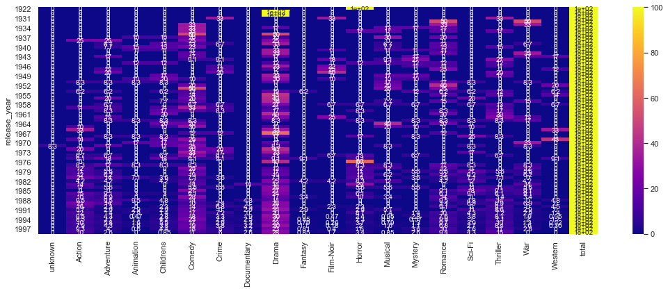

```python
plt.figure(figsize=(18,6))
ax = sns.heatmap(grouped_year, annot=True,cmap='plasma') #display the data using heatmap
```

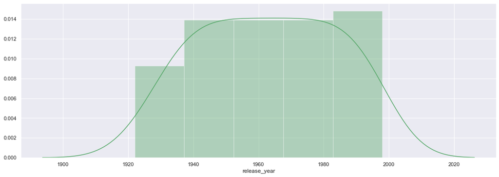

```python
plt.figure(figsize=(18,6)) # for closer look
sns.distplot(grouped_year.index,color='g'); # plotting univariant plot for release_year
```

1. Find the top 25 movies according to average ratings such that each movie has number of ratings more than 100 - 10 marks

Hints :

1. Find the count of ratings and average ratings for every movie.
2. Slice the movies which have ratings more than 100.
3. Sort values according to average rating such that movie which highest rating is on top.
4. Select top 25 movies.
5. You will have to use the .merge() function to get the movie titles.

Note: This question will need you to research about groupby and apply your findings. You can find more on groupby on https://realpython.com/pandas-groupby/.

```python
movies_rating=pd.merge(movies, rating )# merge the two dataframes
movie_rating=pd.DataFrame() #crate a new dataframe
movie_rating['rating_count']=movies_rating.groupby('movie title')['rating'].count() # find the 'rating_count' groupby on 'movie title' and store this value in the dataframe created.
movie_rating= movie_rating[movie_rating['rating_count']>100] #Slice the movies which have ratings more than 100, now we have movie which have 'rating_count' greater than 100 in the dataframe.
movie_rating['rating_mean']=movies_rating.groupby('movie title')['rating'].mean() # find the 'rating_mean' groupby on 'movie title' and store this value in the dataframe created
movie_rating.sort_values("rating_mean", ascending=False).head(25) # Sorting values according to average rating in descending order and select top 25 movies
```

| movie title | rating_count | rating_mean |
| --- | --- | --- |
| Close Shave, A | 112 | 4.491071 |
| Schindler's List | 298 | 4.466443 |
| Wrong Trousers, The | 118 | 4.466102 |
| Casablanca | 243 | 4.456790 |
| Shawshank Redemption, The | 283 | 4.445230 |
| Rear Window | 209 | 4.387560 |
| Usual Suspects, The | 267 | 4.385768 |
| Star Wars | 583 | 4.358491 |
| 12 Angry Men | 125 | 4.344000 |
| Citizen Kane | 198 | 4.292929 |
| To Kill a Mockingbird | 219 | 4.292237 |
| One Flew Over the Cuckoo's Nest | 264 | 4.291667 |
| Silence of the Lambs, The | 390 | 4.289744 |
| North by Northwest | 179 | 4.284916 |
| Godfather, The | 413 | 4.283293 |
| Secrets & Lies | 162 | 4.265432 |
| Good Will Hunting | 198 | 4.262626 |
| Manchurian Candidate, The | 131 | 4.259542 |
| Dr. Strangelove or: How I Learned to Stop Worrying and Love the Bomb | 194 | 4.252577 |
| Raiders of the Lost Ark | 420 | 4.252381 |
| Vertigo | 179 | 4.251397 |
| Titanic | 350 | 4.245714 |
| Lawrence of Arabia | 173 | 4.231214 |
| Maltese Falcon, The | 138 | 4.210145 |
| Empire Strikes Back, The | 367 | 4.204360 |

### 10. See gender distribution across different genres check for the validity of the below statements - 10 marks

- Men watch more drama than women
- Women watch more Sci-Fi than men
- Men watch more Romance than women

**compare the percentages**

1. Merge all the datasets
2. There is no need to conduct statistical tests around this. Just **compare the percentages** and comment on the validity of the above statements.
3. you might want ot use the .sum(), .div() function here.
4. Use number of ratings to validate the numbers. For example, if out of 4000 ratings received by women, 3000 are for drama, we will assume that 75% of the women watch drama.

```python
movie_rating_user=pd.merge(movies_rating, user) # merge all the dataframe
#considering female users only
movie_f = movie_rating_user[movie_rating_user['gender']=='F'] # filter female user and save it in a new dataframe
#considering male users only
movie_m = movie_rating_user[movie_rating_user['gender']=='M'] # filter male user and save it in a new dataframe
movie_f=movie_f[['Drama','Sci-Fi','Romance','rating','gender']] # select only 'Drama','Sci-Fi','Romance','rating','gender' and save it in dataframe
movie_fg = movie_f.groupby('gender').sum()[['Drama','Sci-Fi','Romance']] # find the total no.of movie watched by female in selected genre groupby on 'movie title' and save this value in the dataframe.
movie_fg=(movie_fg.div((movie_f['rating'].count()), axis= 0) * 100) # find how many percentage of female watched different selected genre
movie_m=movie_m[['Drama','Sci-Fi','Romance','rating','gender']] # select only 'Drama','Sci-Fi','Romance','rating','gender' and save it in dataframe
movie_mg = movie_m.groupby('gender').sum()[['Drama','Sci-Fi','Romance']] # find the total no.of movie watched by male in different selected genre groupby on 'movie title' and save this value in the dataframe.
movie_mg=(movie_mg.div((movie_m['rating'].count()), axis= 0) * 100)# find how many percentage of male watched different selected genre
movie_fg
user_fm= pd.concat([movie_fg,movie_mg]) # concat the two dataframe in order to compare the percentages
print ('Compare the percentages:')
print (user_fm)

#on comparing it is clear that women watch more drama and Romance movie in comarison to men.
print ('\nMen watch more drama than women: False')
print ('Women watch more Sci-Fi than men: False')
print ('Men watch more Romance than women: False')
```

```
Compare the percentages:
            Drama     Sci-Fi    Romance
gender
F       42.769446  10.214469  22.760121
M       38.903479  13.603491  18.319799

Men watch more drama than women: False
Women watch more Sci-Fi than men: False
Men watch more Romance than women: False
```